# RegresiLinear

## Regresi Linear

Kelompok 3

1. Abu Dzar Al-Ghifari (50415047)
2. Dimas Ari Pratama (51415918)
3. kevin Aditya Sadewo (53415686)
4. M. Raihan Albab (54415726)
5. Robi Pradana (56415227)
6. Suci Hayati (56415691)

```python
# imports
import pandas as pd
import matplotlib.pyplot as plt

# this allow plots to appear directly in the notebook
%matplotlib inline
```

Pandas adalah sebuah library analisis data yang memiliki struktur data yang kita perlukan untuk membersihkan data mentah ke dalam sebuah bentuk yang cocok untuk analisis (yaitu tabel). Struktur data pada pandas yaitu DataFrame, merupakan struktur data 2D, Data disejajarkan secara tabular dalam baris dan kolom. Pandas DataFrame terdiri dari tiga komponen utama, data, baris, dan kolom.

Matplotlib adalah library Python 2D yang dapat menghasilkan plot dengan kualitas tinggi dalam berbagai format dan dapat digunakan di banyak platform. Matplotlib dapat digunakan sebagai pembuat grafik dalam berbagai platform, seperti Python dan Jupyter. Grafik yang dapat dibuat beragam, seperti grafik garis, batang, lingkaran, histogram, dsb.

```python
# read data into a DataFrame
data = pd.read_csv('http://www-bcf.usc.edu/~gareth/ISL/Advertising.csv', index_col=0)
data.head()
```

|  | TV | radio | newspaper | sales |
| --- | --- | --- | --- | --- |
| 1 | 230.1 | 37.8 | 69.2 | 22.1 |
| 2 | 44.5 | 39.3 | 45.1 | 10.4 |
| 3 | 17.2 | 45.9 | 69.3 | 9.3 |
| 4 | 151.5 | 41.3 | 58.5 | 18.5 |
| 5 | 180.8 | 10.8 | 58.4 | 12.9 |

membaca data dengan format csv, mengambil data dari link tersebut, dan menampilkan data 5 teratas

```python
# print the shape of DataFrame
data.shape
```

```
(200, 4)
```

data.shape untuk menampilkan jumlah dataframe baris dan kolom, terdapat 200 baris dan 4 kolom (TV, Newspaper, Radio, dan Sales)

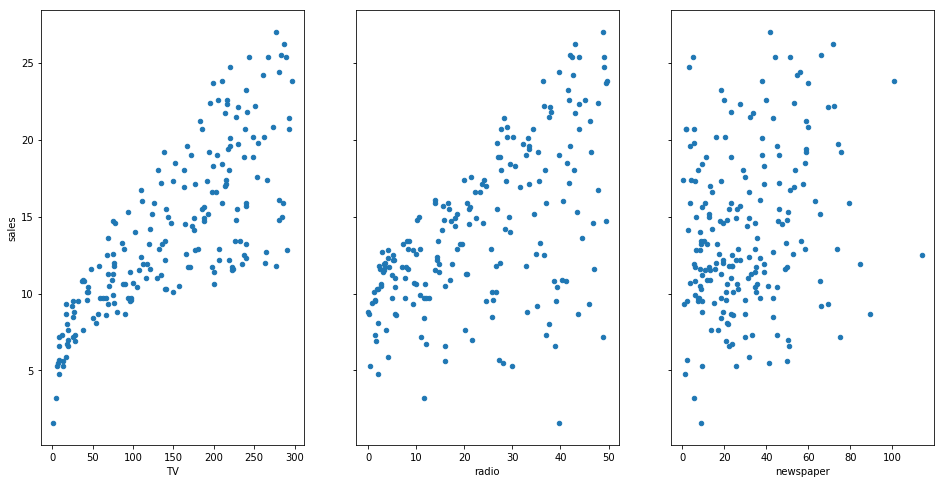

```python
fig, axs = plt.subplots(1, 3, sharey=True)
data.plot(kind='scatter', x='TV', y='sales', ax=axs[0], figsize=(16, 8))
data.plot(kind='scatter', x='radio', y='sales', ax=axs[1])
data.plot(kind='scatter', x='newspaper', y='sales', ax=axs[2])
```

menampilkan 3 data grafik dengan fungsi data.plot, kind untuk menentukan tipe grafik dengan menggunakan scatter, x untuk label sumbu x, dan y untuk label sumbu y, figsize untuk ukuran gambar nya 16x8

```python
# this is the standard import if you're usig "formula notation" (similiar to R)
import statsmodels.formula.api as smf

# create a fitted model in one line
lm = smf.ols(formula='sales ~ TV', data=data).fit()

# print the coefficients
lm.params
```

```
Intercept    7.032594
TV           0.047537
dtype: float64
```

mengimport statsmodels.formula.api untuk melakukan perhitungan dengan mendefinisikan variabel lm = smf.ols kemudian memformulasikan data sales ~ TV

```python
# manually calculate the prediction
7.032594 + 0.047537*50
```

```
9.409444
```

melakukan perhitungan manual untuk prediksi harga 50

```python
# you have to create a DataFrame since the Statsmodels formula interface expects it
X_new = pd.DataFrame({'TV': [50]})
X_new.head()
```

|  | TV |
| --- | --- |
| 0 | 50 |

```python
# use the model to make predictions on a new value
lm.predict(X_new)
```

```
0    9.409426
dtype: float64
```

memprediksi menggunakan model lm dengan nilai x_new

```python
# print the R-squared valued for the model
lm.rsquared
```

```
0.611875050850071
```

untuk menampilkan perhitungan R kuadrat

```python
# create a DataFrame with the minimum and maximum values of TV
X_new = pd.DataFrame({'TV': [data.TV.min(), data.TV.max()]})
X_new.head()
```

|  | TV |
| --- | --- |
| 0 | 0.7 |
| 1 | 296.4 |

untuk menampilkan dataframe dari kolom tv, mengambil data TV minimal dan data TV maksimal

```python
# make predictions fot those x values and store them
preds = lm.predict(X_new)
preds
```

```
0     7.065869
1    21.122454
dtype: float64
```

mendefinisikan variable preds menggunakan model lm.predict dengan x_new kemudian menampilkan hasil prediksi

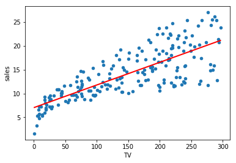

```python
# first, plot the observed data
data.plot(kind='scatter', x='TV', y='sales')

# then, plot the Least squares Line
plt.plot(X_new, preds, c='red', linewidth=2)
```

menampilkan figure data dengan plot scatter didefinisikan sumbu x = TV (data) dan sumbu y = sales dan menampilkan garis berwarna merah yang bernilai prediksi dari nilai x_new sampai nilai prediksi (preds) dengan lebar 2